# Flight Delay Data Exploration

## by Walid Naous

## Investigation Overview

The aim of this presentation is to explore flight delay in the UD domestric air travel during the busiest month of the year 2018 - July. This presenatation will try to highlight which airline, origin airport and time of the flight may have the most delay

## Dataset Overview

The dataset used was downloaded from http://stat-computing.org for the year 2018 and Month of July. The dataset included, flight time, cariier ID, Origin airport, planned departuret time ,Actual Departure time, delay in minutes, planned arrival time, actual arrival time

## Departing Delay

The following visulization will explore the number of delayed flight (Main variable) throughout the month of July.>It is observed that the departing delay is right skewed with high number of delay between 0 and 12 minuts (within the 75% percentile).

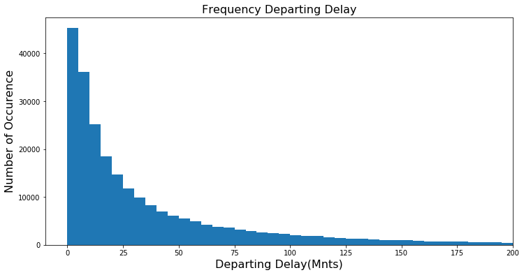

```python
binsize = 5
bins = np.arange(0, df_flights['dep_delay_duration'].max()+binsize, binsize)
plt.figure(figsize=[12, 6])
plt.hist(data = df_flights, x = 'dep_delay_duration', bins = bins)
plt.xlim([-10,200])
plt.title('Frequency Departing Delay' , fontsize = 16)
plt.xlabel('Departing Delay(Mnts)', fontsize = 16)
plt.ylabel('Number of Occurence', fontsize = 16)
plt.show()
```

## Carriers Frequency Delay

The following visulization will highlight which airlines have the most delay during the month of July 2018. Southwest airline along with Delta Airline and American Airline are have the highest occurence of delay frequency.

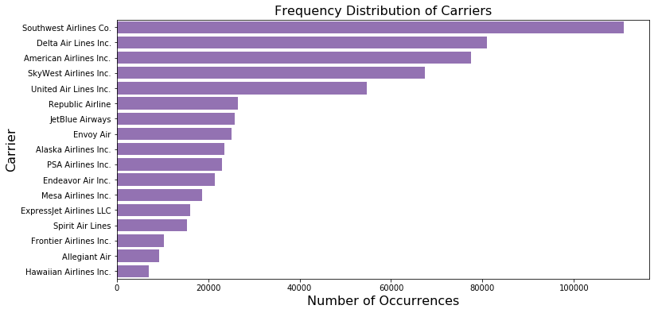

```python
## Ploting cariiers delay frequency
plt.figure(figsize=(12, 6))
default_color = sn.color_palette()[4]
carrier_order = df_flights['carrier_code'].value_counts().index
sn.countplot(data=df_flights, y='carrier_code',color=default_color, order=carrier_order)

plt.title('Frequency Distribution of Carriers', fontsize = 16)
plt.xlabel('Number of Occurrences', fontsize=16)
plt.ylabel('Carrier', fontsize=16);
```

## Origin Airport Delay

For the benefit of our analysis, We will use top 50 airports associated with the highest number of Frequency in which flights are delayed. It is observed that Atlanta airport has the highest occurence of flight delay followed by Chicago airport and Dallas/FortWotrth. Moreover, it is also noted that there a drop between 1st and 2nd place all the to 6th place. After the 6th place, the ferequency of delay occurence decrease steadilty.

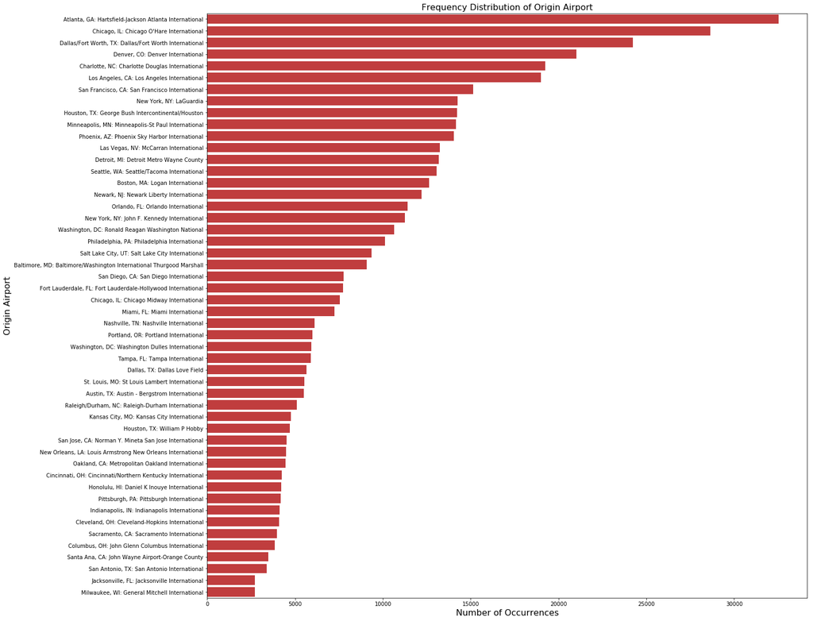

```python
  #Select the Top 50 Airports for this analysis since there are more than 350 airports to work with which make the graph very crowded

default_color = sn.color_palette()[3]
carrier_order = df_flights['origin'].value_counts().head(50).index

plt.figure(figsize=(20, 20))

sn.countplot(data=df_flights, y='origin',color=default_color,order=carrier_order)


plt.title('Frequency Distribution of Origin Airport', fontsize = 16)
plt.xlabel('Number of Occurrences', fontsize=16)
plt.ylabel('Origin Airport', fontsize=16);
```

## Time of Day Delay

Flight departure time is one of the most intresting variable to review and analyze. There is quite common frequency of delay between 6 am and 6 pm throughout the day. In addition, the 6 am flight had shown the highest number of departure delay occurence.

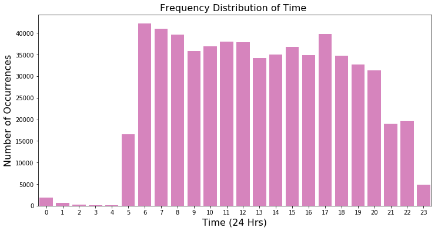

```python
plt.figure(figsize=(12, 6))
default_color = sn.color_palette()[6]

carrier_count = df_flights['planned_dep_time'].value_counts()
sn.barplot(carrier_count.index, carrier_count.values, color = default_color)

plt.title('Frequency Distribution of Time ',fontsize=16)
plt.ylabel('Number of Occurrences', fontsize=16)
plt.xlabel('Time (24 Hrs)', fontsize=16)
plt.show()
```

## Delay duration frequency per airline

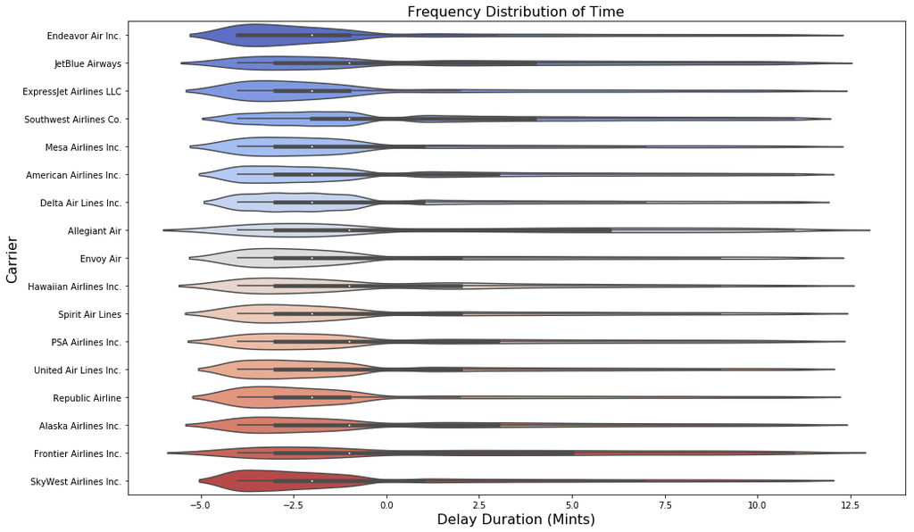

```python
# Only select data between 25 and 75 percentile in order to remove outliers
df_flights_no_outliers = df_flights.loc[(df_flights.dep_delay_duration < df_flights.dep_delay_duration.quantile(0.75)) &
                           (df_flights.dep_delay_duration > df_flights.dep_delay_duration.quantile(0.25))].copy()


#Create strip plot in seaborn violinplot for Carrier Vs Delay duration
plt.figure(figsize=(16, 10))

sn.violinplot(y= "carrier_code", x= "dep_delay_duration", data=df_flights_no_outliers,palette="coolwarm")

plt.title('Frequency Distribution of Time' , fontsize=16)
plt.ylabel('Carrier', fontsize=16)
plt.xlabel('Delay Duration (Mints)', fontsize=16)

plt.show()
```

### Carrier & Time of departure

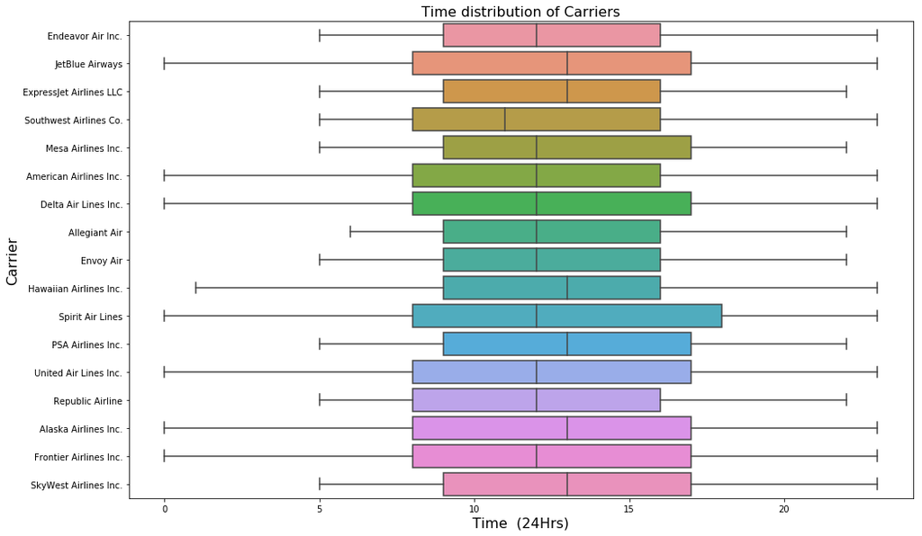

```python
#Create strip plot in seaborn violinplot for Carrier Vs Time of Flight
plt.figure(figsize=(16, 10))

sn.boxplot(data=df_flights_no_outliers, y= "carrier_code", x= "planned_dep_time")

plt.title('Time distribution of Carriers' , fontsize=16)
plt.xlabel('Time  (24Hrs)', fontsize=16)
plt.ylabel('Carrier', fontsize=16)

plt.show()
```

```python
!jupyter nbconvert Explanation_slide_deck.ipynb --to slides --post serve --template output_toggle
```